# Analisis Exploratorio de Datos enfocado en Seguridad

Fradin Gomez, Lucas Tomas. Barbetta, Rocio Jacqueline. Cruz, Santiago Jonas. Aranda, Franco Gabriel. Tapia Zahira Dominique.

2025-06-09

# Introducción

El presente trabajo se centra en el análisis sobre la delincuencia en el **Conurbano Bonaerense**. Si bien el dataset seleccionado proporciona información sobre hechos delictivos contra la propiedad en la provincia de Buenos Aires, hemos delimitado nuestro estudio al Conurbano Bonaerense, ya que puede beneficiar a un análisis más detallado. El interés por esta temática surge a razón de la percepción de la preocupación de la población de la zona en la que vivimos, puesto que en el dia a dia, no solo nos cruzamos con noticias en las pantallas de la televisión anunciando alguna clase de hecho delictivo, también le acontecen a seres cercanos, reafirmando la preocupación que se convierte en personal.

### Descripción del dataset

El dataset, proporcionado por el **Ministerio de Seguridad de la Provincia de Buenos Aires**, que se nutrio como fuente primaria del **Sistema Nacional de Información Criminal perteneciente a la Dirección Nacional de Estadística Criminal** bajo el Ministerio de Seguridad de la Nación. contiene las siguientes variables: Año: periodo del registro (cualitativa ordinal) Aunque se ve como número su función es temporal y secuencial. Municipio: jurisdicción dentro de la provincia de Buenos Aires (cualitativa nominal) no tiene orden inherente. Tipo de hecho delictivo: clasificado en “total de hechos de robos” y “total de hechos de hurtos” (cualitativa nominal) clasifica el hecho; es categórica sin jerarquía. Valor: cantidad absoluta de delitos registrados (cuantitativa discreta). Es una variable numérica entera, y puede realizarse sobre ella operaciones matemáticas. Periodo: fecha correspondiente al año en formato extendido. (cuantitativa continua). Es redundante con la variable año, pero es útil si se requiere un tipo de fecha. La institución es una fuerte, confiable y reconocida en el ámbito de la seguridad pública, y su base de datos es ampliamente utilizada por investigadores. Por tanto, debido a su vigencia, confiabilidad y relevancia social fue que decidimos utilizar este dataset en nuestro análisis. Además, la información oficial permite trabajar con datos sistemáticos, comparables entre municipios y a lo largo del tiempo.

## Objetivos del análisis

Mediante técnicas estadísticas y de análisis de datos buscaremos explorar las variables contenidas en nuestro dataset e identificar patrones y tendencias significativas, con el fin de confirmar o refutar la siguiente hipótesis:

**Hipótesis principal:**  
“En el último tiempo, la tendencia de los hechos delictivos en contra de la propiedad ha ido al alza”.

De esta misma, se desprenden preguntas para amplificar el contenido de la hipótesis, tales como:

- ¿Cuáles son las **tendencias y patrones** en la delincuencia del Conurbano Bonaerense en los últimos años?
- ¿Existen **diferencias significativas** en la delincuencia entre diferentes municipios del Conurbano, es decir, ¿hay dispersión en los datos?
- ¿Cuál es el **municipio que presenta mayor incidencia** de hechos delictivos?

Esperamos generar **respuestas visuales relevantes** a cada una de las incógnitas y llegar a una **conclusión** acerca de nuestras dudas.

# Limpieza y Preparación de Datos

```r
library(dplyr)

ruta <- ("C:/Users/estudiante/OneDrive/Documents/Lucas/UNAB/Recoleccion de Datos y Analisis Primario de la Informacion/Pasan filtro pa tp/062_hechos-delictuosos-contra-la-propiedad-por-municipio.-provincia-de-buenos-aires.-anos-2014-2.csv")

#Se hace la carga de los datos, indicando un idioma para que identifique las ñ y caracteres especiales, propios del castellano, ademas se indica la presencia de un encabezado y la separacion que tienen los datos, uno de otro.
data_seguridad <- read.csv(ruta, fileEncoding = "latin1", header = TRUE, sep = ";")

#Para eliminar las columnas que vienen demas se aplica una condicion que busca los valores nulos, dejandolo las columnas si se registra algun valor no NA, eliminandola es el opuesto.
data_seguridad <- data_seguridad[, colSums(!is.na(data_seguridad)) > 0]

#Queremos visualizar los tipos de dato que existen en el dataset
glimpse(data_seguridad)
```

```
## Rows: 2,176
## Columns: 5
## $ periodo   <chr> "1/1/2014", "1/1/2014", "1/1/2015", "1/1/2015", "1/1/2016", …
## $ Año       <int> 2014, 2014, 2015, 2015, 2016, 2016, 2017, 2017, 2018, 2018, …
## $ Municipio <chr> "Total general", "Total general", "Total general", "Total ge…
## $ Tipo      <chr> "Total de hechos de hurtos", "Total de hechos de robos", "To…
## $ Valor     <chr> "54902", "88518", "51451", "81396", "52909", "81286", "51661…
```

## Corrección de formatos

```r
#Habiendo detectado que la columna valor y el perido no cumplen con sus tipos, se procede a arreglarlos

data_seguridad$Valor <- as.numeric(data_seguridad$Valor)
data_seguridad$periodo <- as.Date(data_seguridad$periodo, format = "%d/%m/%Y", tryFormats = c("%d/%m/%Y"))

#Forma de ubicar en que filas estan los NA, puesto que fueron en Valor
data_seguridad[is.na(data_seguridad$Valor), ]
```

```
##         periodo  Año     Municipio                      Tipo Valor
## 748  2019-01-01 2019 General Guido  Total de hechos de robos    NA
## 1146 2018-01-01 2018        Lezama  Total de hechos de robos    NA
## 1520 2021-01-01 2021    Pellegrini  Total de hechos de robos    NA
## 1766 2016-01-01 2016    Salliqueló  Total de hechos de robos    NA
## 1770 2018-01-01 2018    Salliqueló  Total de hechos de robos    NA
## 2004 2015-01-01 2015      Tordillo  Total de hechos de robos    NA
## 2006 2016-01-01 2016      Tordillo  Total de hechos de robos    NA
## 2008 2017-01-01 2017      Tordillo  Total de hechos de robos    NA
## 2010 2018-01-01 2018      Tordillo  Total de hechos de robos    NA
## 2012 2019-01-01 2019      Tordillo  Total de hechos de robos    NA
## 2014 2020-01-01 2020      Tordillo  Total de hechos de robos    NA
## 2081 2014-01-01 2014   Tres Lomas  Total de hechos de hurtos    NA
## 2082 2014-01-01 2014   Tres Lomas   Total de hechos de robos    NA
```

```r
#Se cambiaron los valores NA por 0, debido a que no afectan al filtro, pero se quiere limpiar la base de datos
data_seguridad$Valor[is.na(data_seguridad$Valor)] <- 0

#Volvemos a verificar

any(is.na(data_seguridad))
```

```
## [1] FALSE
```

```r
#Dio FALSE, por lo tanto ya esta limipio

#Volvemos a chequear los tipos de datos
glimpse(data_seguridad)
```

```
## Rows: 2,176
## Columns: 5
## $ periodo   <date> 2014-01-01, 2014-01-01, 2015-01-01, 2015-01-01, 2016-01-01,…
## $ Año       <int> 2014, 2014, 2015, 2015, 2016, 2016, 2017, 2017, 2018, 2018, …
## $ Municipio <chr> "Total general", "Total general", "Total general", "Total ge…
## $ Tipo      <chr> "Total de hechos de hurtos", "Total de hechos de robos", "To…
## $ Valor     <dbl> 54902, 88518, 51451, 81396, 52909, 81286, 51661, 81056, 6314…
```

## Creación de nuevas variables

```r
#Variable que servira a modo de filtro para la estructura de los datos
partidos_conurbano <- c("Almirante Brown", "Avellaneda", "Berazategui", "Esteban Echeverría", "Ezeiza", "Florencio Varela", "José C. Paz", "La Matanza", "Lanús", "Lomas de Zamora", "Malvinas Argentinas", "Merlo", "Moreno", "Quilmes", "San Fernando", "San Isidro", "San Miguel", "San Vicente", "Tigre", "Tres de Febrero", "Vicente López", "Hurlingham", "Ituzaingó")
data_seguridad_filtrado <- data_seguridad[data_seguridad$Municipio %in% partidos_conurbano, ]
glimpse(data_seguridad_filtrado)
```

```
## Rows: 368
## Columns: 5
## $ periodo   <date> 2014-01-01, 2014-01-01, 2015-01-01, 2015-01-01, 2016-01-01,…
## $ Año       <int> 2014, 2014, 2015, 2015, 2016, 2016, 2017, 2017, 2018, 2018, …
## $ Municipio <chr> "Almirante Brown", "Almirante Brown", "Almirante Brown", "Al…
## $ Tipo      <chr> "Total de hechos de hurtos", "Total de hechos de robos", "To…
## $ Valor     <dbl> 1271, 1962, 1225, 2355, 1135, 2204, 1262, 2403, 1175, 2171, …
```

```r
#Verificamos si exiten datos NA luego de haberlos filtrado
any(is.na(data_seguridad_filtrado))
```

```
## [1] FALSE
```

# Análisis Exploratorio

### Preguntas de análisis

Volviendo a las preguntas plantedas en la introducción del presente trabajo practico:

- ¿Cuáles son las **tendencias y patrones** en la delincuencia del Conurbano Bonaerense en los últimos años?
- ¿Existen **diferencias significativas** en la delincuencia entre diferentes municipios del Conurbano, es decir, ¿hay dispersión en los datos?
- ¿Cuál es el **municipio que presenta mayor incidencia** de hechos delictivos?

```r
#Para conocer las tendencias, debido a que hay datos para cada municipio y se quiere conocer el total, se agrupa por año.
total_anual2 <- data_seguridad_filtrado %>%
  group_by(Año, Tipo) %>%
  summarise(total_hechos = sum(Valor, na.rm = TRUE)) %>%
  arrange(Año, Tipo)
print(total_anual2)
```

```
## # A tibble: 16 × 3
## # Groups:   Año [8]
##      Año Tipo                      total_hechos
##    <int> <chr>                            <dbl>
##  1  2014 Total de hechos de hurtos        28739
##  2  2014 Total de hechos de robos         56812
##  3  2015 Total de hechos de hurtos        27495
##  4  2015 Total de hechos de robos         52557
##  5  2016 Total de hechos de hurtos        28439
##  6  2016 Total de hechos de robos         51272
##  7  2017 Total de hechos de hurtos        28846
##  8  2017 Total de hechos de robos         52500
##  9  2018 Total de hechos de hurtos        35767
## 10  2018 Total de hechos de robos         63962
## 11  2019 Total de hechos de hurtos        57317
## 12  2019 Total de hechos de robos        100036
## 13  2020 Total de hechos de hurtos        36798
## 14  2020 Total de hechos de robos         73851
## 15  2021 Total de hechos de hurtos        40803
## 16  2021 Total de hechos de robos         72803
```

```r
#Queremos conocer algunas medidas, como la media, mediana y el desvio.
#Creamos una variable que agrupa por el año y tambien por municipio, sumando ambos tipos porque sino tendremos municipios de mas
total_hechos_por_año <- data_seguridad_filtrado %>%
  group_by(Año, Municipio) %>%
  summarise(total_valor = sum(Valor, na.rm = TRUE)) %>%
  ungroup()
#Ahora que tenemos los datos unificados, agrupamos por año y vamos calculando las medidas en base a la columna Valor
estadisticas_totales_por_año <- total_hechos_por_año %>%
  group_by(Año) %>%
  summarise(
    media = mean(total_valor, na.rm = TRUE),
    mediana = median(total_valor, na.rm = TRUE),
    desviacion = sd(total_valor, na.rm = TRUE),
    minimo = min(total_valor, na.rm = TRUE),
    maximo = max(total_valor, na.rm = TRUE),
    n = n()
  ) %>%
  arrange(Año)

#Para visualizar las mencionadas
print(estadisticas_totales_por_año)
```

```
## # A tibble: 8 × 7
##     Año media mediana desviacion minimo maximo     n
##   <int> <dbl>   <dbl>      <dbl>  <dbl>  <dbl> <int>
## 1  2014 3720.    2757      2831.    484  13784    23
## 2  2015 3481.    2878      2543.    502  11808    23
## 3  2016 3466.    2850      2480.    591  12021    23
## 4  2017 3537.    2984      2639.    734  13439    23
## 5  2018 4336.    3405      3462.    637  17084    23
## 6  2019 6841.    5423      6590.   1127  34631    23
## 7  2020 4811.    3428      4553.    777  23300    23
## 8  2021 4939.    3767      4729.    817  24310    23
```

```r
#Se agrupan los datos en años y municipios para conocer cuales son los 5 municipios que registran mas hechos por año
top_municipios_ano <- data_seguridad_filtrado %>%
  group_by(Año, Municipio) %>%
  summarise(total_hechos = sum(Valor, na.rm = TRUE), .groups = 'drop') %>%
  group_by(Año) %>%
  slice_max(total_hechos, n = 5, with_ties = FALSE) %>%
  arrange(Año, desc(total_hechos))
print(top_municipios_ano)
```

```
## # A tibble: 40 × 3
## # Groups:   Año [8]
##      Año Municipio       total_hechos
##    <int> <chr>                  <dbl>
##  1  2014 La Matanza             13784
##  2  2014 Tres de Febrero         7955
##  3  2014 Quilmes                 6996
##  4  2014 Lomas de Zamora         6303
##  5  2014 Lanús                   4676
##  6  2015 La Matanza             11808
##  7  2015 Tres de Febrero         7719
##  8  2015 Lomas de Zamora         6374
##  9  2015 Quilmes                 6232
## 10  2015 Moreno                  4714
## # ℹ 30 more rows
```

```r
#Como el valor atipico en la tendencia es 2019, se decide aplicar un filtro a lo anterior para este año, con el fin de visualizarlo
top_2019 <- top_municipios_ano %>% filter(Año == 2019)

#Sirve para encontrar el partido que mayor incidencia registra en hechos
partido_top <- data_seguridad_filtrado %>%
  group_by(Municipio) %>%
  summarise(total = sum(Valor, na.rm = TRUE)) %>%
  arrange(desc(total)) %>%
  slice(1) %>%
  pull(Municipio)
print(partido_top)
```

```
## [1] "La Matanza"
```

```r
#Con esto se fitra el dataset para que solo sean extraidos el partido de interes
datos_top_municipio <- data_seguridad_filtrado %>%
  filter(Municipio == partido_top)
```

## Visualización de datos

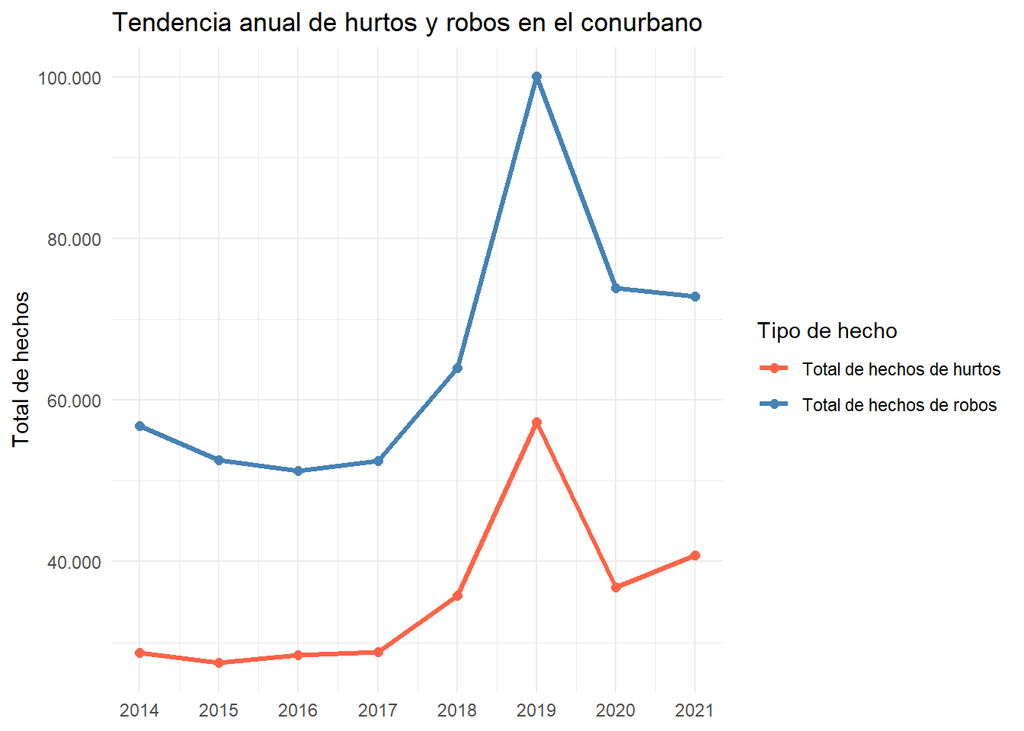

```r
options(repos = c(CRAN = "https://cloud.r-project.org/"))
library(ggplot2)
install.packages("scales")
install.packages("scales", repos = "https://cloud.r-project.org/")
library(scales)

ggplot(total_anual2, aes(x = Año, y = total_hechos, color = Tipo, group = Tipo)) +
  geom_line(linewidth = 1.2) +
  geom_point(size = 2) +
  labs(
    title = "Tendencia anual de hurtos y robos en el conurbano",
    y = "Total de hechos",
    color = "Tipo de hecho"
  ) +
  theme_minimal() +
  theme(axis.title.x = element_blank()) +
  scale_color_manual(values = c("Total de hechos de hurtos" = "tomato",
                                "Total de hechos de robos" = "steelblue")) +
  scale_x_continuous(breaks = 2014:2021) +
  scale_y_continuous(labels = label_comma(big.mark = ".", decimal.mark = ","))
```

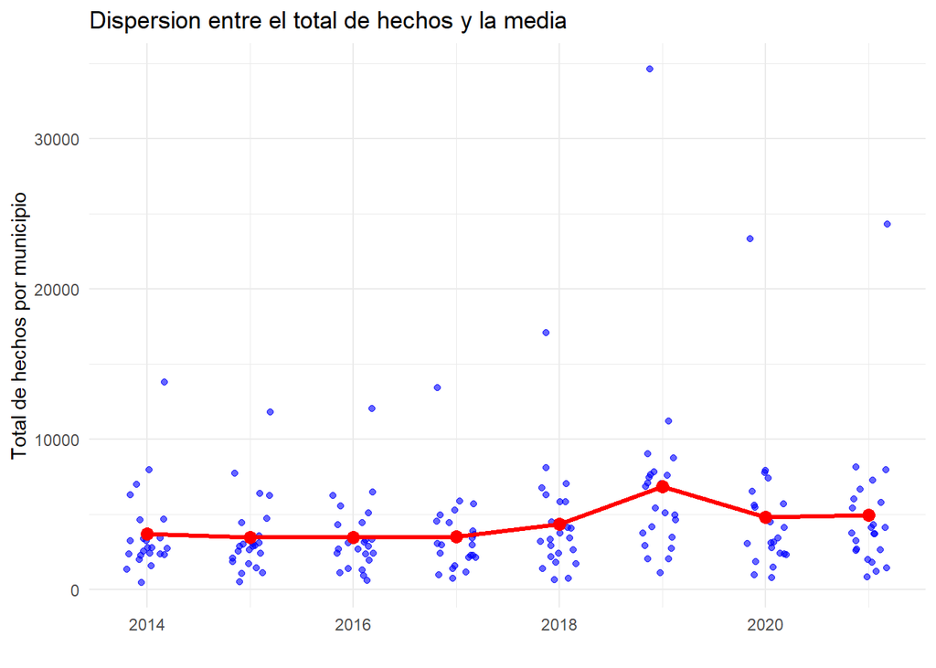

```r
ggplot(total_hechos_por_año, aes(x = Año, y = total_valor)) +
  geom_jitter(width = 0.2, height = 0, alpha = 0.6, color = "blue") +
  geom_line(data = estadisticas_totales_por_año, aes(x = Año, y = media), color = "red", size = 1.2) +
  geom_point(data = estadisticas_totales_por_año, aes(x = Año, y = media), color = "red", size = 3) +
  labs(
    title = "Dispersion entre el total de hechos y la media",
    x = "",
    y = "Total de hechos por municipio"
  ) +
  theme_minimal()
```

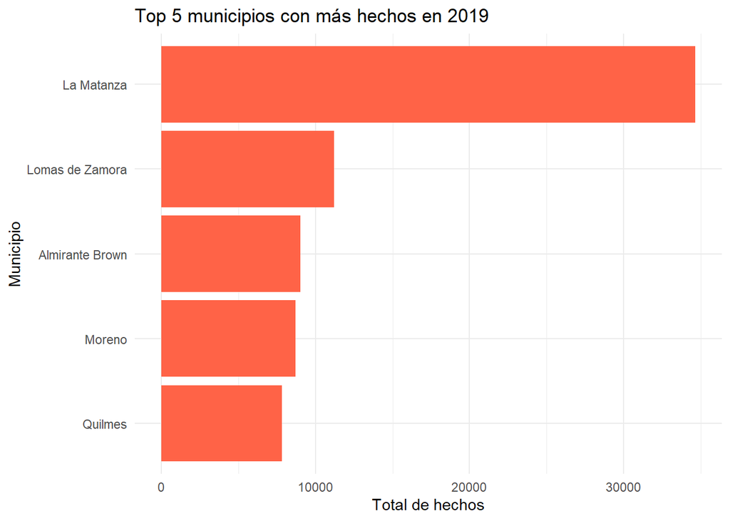

```r
ggplot(top_2019, aes(x = reorder(Municipio, total_hechos), y = total_hechos)) +
       geom_col(fill = "tomato") +
       coord_flip() +
       labs(
             title = "Top 5 municipios con más hechos en 2019",
             x = "Municipio",
              y = "Total de hechos"
            ) +
        theme_minimal()
```

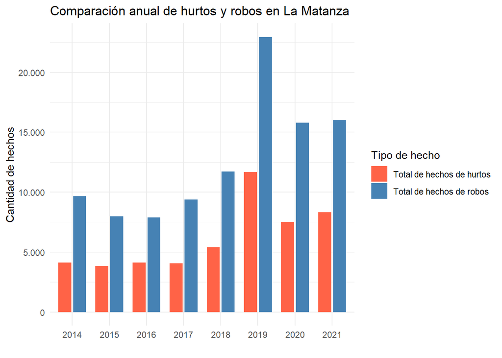

```r
ggplot(datos_top_municipio, aes(x = factor(Año), y = Valor, fill = Tipo)) +
  geom_col(position = position_dodge(width = 0.8), width = 0.7) +
  labs(
    title = paste("Comparación anual de hurtos y robos en", partido_top),
    y = "Cantidad de hechos",
    x = "",
    fill = "Tipo de hecho"
  ) +
  theme_minimal() +
  scale_fill_manual(values = c("Total de hechos de hurtos" = "tomato",
                               "Total de hechos de robos" = "steelblue")) +
  scale_y_continuous(labels = function(x) format(x, big.mark = ".", decimal.mark = ","))
```

# Conclusiones

A modo de conclusión podemos mencionar los hallazgos que surgieron del presente análisis exploratorio de datos. Se confirmo que la tendencia de los hechos delictivos contra la propiedad privada en el conurbano, en el lapso analizado, 2014-2021, fue al alza, mostrando un valor atípico en forma de pico en el año 2019. No sé puede afirmar que exista alguna zona del conurbano que haya sido más insegura, puesto que a pesar de las diferencias en los hechos, en un top 5 del año con en el que se registra el pico, hay partidos de diferentes zonas del área en analisis. Gracias a las medidas estadísticas, se pudo dilucidar que existe una diferencia entre la media y la desviación estándar relevante, lo que habla de valores atípicos o muy altos que están impulsando dicho desvío. Finalmente, al filtrar y calcular la información se llegó al partido con mayor incidencia de los hechos en el conurbano, siendo este, La Matanza.

## Reflexiones finales

Como reflexión final, hemos tomado en cuenta los hallazgos principales que, pese ser satisfactorios y efectivos para los objetivos planteados para el análisis, podría ser aún mejores, o más cercanos al contexto socio-economico. ¿Cómo?, aportando datos externos, o sumando los mismos. Vemos que se nos muestra un pico en 2019 de hurtos y robos, esto nos permite sacar conclusiones variadas con un fundamento estable, pero podríamos adherir datos complementarios que nos servirán para despejar dudar y realizar un análisis más completos. A modo de ejemplo, podríamos plantear una nueva incógnita: ¿Por qué hubo tantos robos en 2019? Normalmente se asocia que hay cada vez más robos como causa de gente que no tiene salidas laborales, esto lleva a lo siguiente, ¿que tanto desempleo hubo en ese momento?, lo que también podria hacer que nos planteemos, ¿que relación tiene el nivel de ingreso y la inflación como causa de hurtos y robos? El Instituto Nacional de Estadísticas y Censos (INDEC) de nuestro país, podría darnos un acercamiento, el mencionado informa en su pagina que entre el primer semestre del 2018 y el primer semestre del 2019, la pobreza aumento del 19,6% a 25,4% a nivel nacional, en el Gran Buenos Aires, este indice escalo del 31,9% al 35,9%. A su vez, este ente da cuenta de un Indice de Precios al Consumidor para el Gran Buenos Aires del 52,9% a diciembre del 2019, siendo acompañado por un desempleo del 11,1% para el tercer trimestre de este mismo año. Suponiendo que estos factores anteriormente mencionados influyen directamente en la tendencia de los hurtos y robos. Esto no solo portaria mas aristas de estudio, sino también permitiría un análisis más amplio para arribar a conclusiones más certeras y cercanas al contexto económico, social y cultural del Conurbano Bonaerense.

### Fuentes

- Datos Abiertos Estadística PBA: https://datos.estadistica.ec.gba.gov.ar/
- Hechos delictuosos contra la propiedad por municipio: https://datos.estadistica.ec.gba.gov.ar/dataset/hechos-delictuosos-contra-la-propiedad-por-municipio
- Instituto Nacional de Censos y Estadisticas: https://www.indec.gob.ar/
- Indice de Precios al Consumidor (INDEC): https://www.indec.gob.ar/indec/web/Institucional-Indec-InformesTecnicos-31
- Informe de Incidencia en la Pobreza e Indigencia(INDEC): https://www.indec.gob.ar/indec/web/Institucional-Indec-InformesTecnicos-152
- Informe sobre los Mercados de Trabajo(INDEC): https://www.indec.gob.ar/indec/web/Institucional-Indec-InformesTecnicos-58